# STA 101 - HW 6

Mingyi Xue

May 31, 2018

### Load datasets into current workspace

```
##   Rating     Eye  Gen
## 1     11 present Male
## 2      7 present Male
## 3     12 present Male
```

```
##   Sodium Brand
## 1   24.4     A
## 2   22.6     A
## 3   23.8     A
```

```
##    Sod Sub Sup
## 1 1200   I   A
## 2 1400   I   A
## 3 1350   I   A
```

### Install and load packages

```r
library(ggplot2)
library('lme4')
library(nlme)
```

### Problem 1

**(a)**

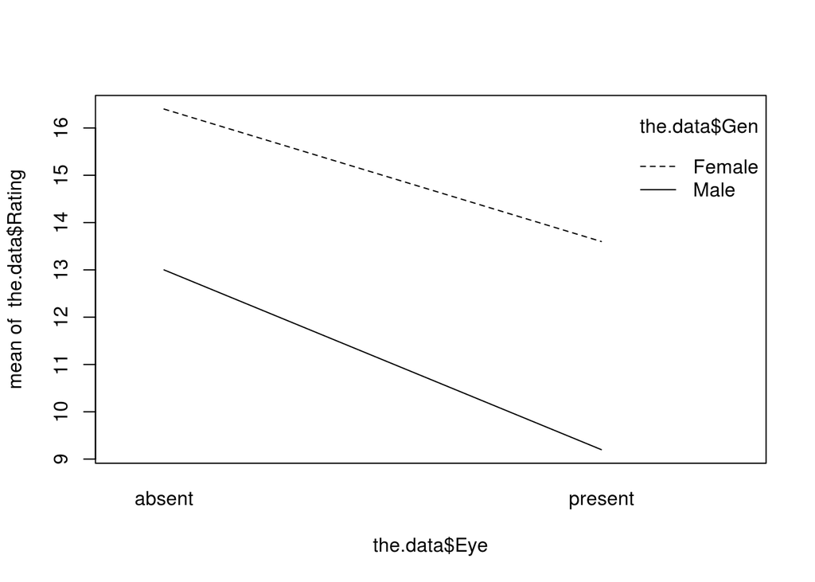

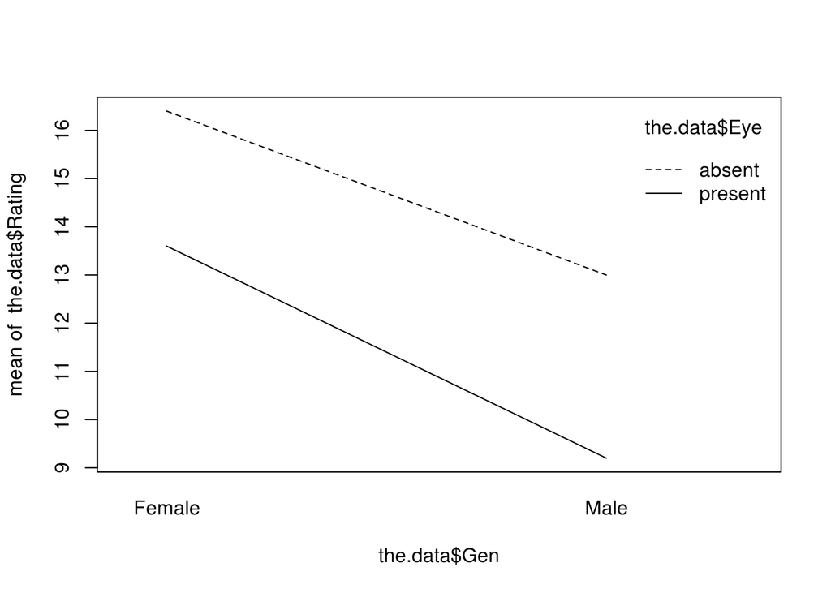

Since two lines are approximately parallel, it suggests no significant interactions.

**(b)**

```
## Analysis of Variance Table
##
## Model 1: Rating ~ Eye + Gen
## Model 2: Rating ~ Eye * Gen
##   Res.Df   RSS Df Sum of Sq      F Pr(>F)
## 1     17 98.45
## 2     16 97.20  1      1.25 0.2058 0.6562
```

$H_{0}$ : $(\gamma\delta)_{ij} = 0$.  
$H_{A}$ : Some $(\gamma\delta)_{ij} \neq 0$.  
Test-statistic : $F_{s} = \frac{SSE_{s}-SSE_{L}}{dof(M_{s})-dof(M_{L})}/ \frac{SSE_{L}}{dof(M_{L})} = 0.2058$.  
P-value equals 0.6562.  
Since p-value is large enough for us to fail to reject $H_{0}$ ($0.6562 >\alpha = 0.10$), so we can conclude that the interaction term between eye contact and gender can be dropped from the model.

**(c)**

```
## Analysis of Variance Table
##
## Model 1: Rating ~ Gen
## Model 2: Rating ~ Eye + Gen
##   Res.Df    RSS Df Sum of Sq      F   Pr(>F)
## 1     18 152.90
## 2     17  98.45  1     54.45 9.4022 0.006991 **
## ---
## Signif. codes:  0 '***' 0.001 '**' 0.01 '*' 0.05 '.' 0.1 ' ' 1
```

$H_{0}$ : $\gamma_{i} = 0$.  
$H_{A}$ : Some $\gamma_{i} \neq 0$.  
Test-statistic : $F_{s} = \frac{SSE_{s}-SSE_{L}}{dof(M_{s})-dof(M_{L})}/ \frac{SSE_{L}}{dof(M_{L})} = 9.4022$.  
P-value equals 0.006991.  
Since p-value is small enough for us to reject $H_{0}$ ($0.006991 <\alpha = 0.10$), so we can conclude that the larger model fits better and the factor of eye contact has a significant effect on the rating.

**(d)**

```
## Analysis of Variance Table
##
## Model 1: Rating ~ Eye
## Model 2: Rating ~ Eye + Gen
##   Res.Df    RSS Df Sum of Sq      F   Pr(>F)
## 1     18 174.50
## 2     17  98.45  1     76.05 13.132 0.002098 **
## ---
## Signif. codes:  0 '***' 0.001 '**' 0.01 '*' 0.05 '.' 0.1 ' ' 1
```

$H_{0}$ : $\delta_{i} = 0$.  
$H_{A}$ : Some $\delta_{i} \neq 0$.  
Test-statistic : $F_{s} = \frac{SSE_{s}-SSE_{L}}{dof(M_{s})-dof(M_{L})}/ \frac{SSE_{L}}{dof(M_{L})} = 13.132$.  
P-value equals 0.002098.  
Since p-value is small enough for us to reject $H_{0}$ ($0.002098 <\alpha = 0.10$), so we can conclude that the larger model fits better and the factor of gender has a significant effect on the rating.

### Problem 2

**(a)**

```
## $Mu..
## [1] 13.05
##
## $Gam
##  absent present
##    1.65   -1.65
##
## $Del
## Female   Male
##   1.95  -1.95
##
## $GamDel
##         Female Male
## absent       0    0
## present      0    0
```

absent+Female appears to have the highest rating.

**(b)**

```
##  absent present
##    1.65   -1.65
```

**(c)**

```
## Female   Male
##   1.95  -1.95
```

**(d)**

```
##         Female Male
## absent       0    0
## present      0    0
```

### Problem 3

**(a)**

```
## (1)absent+(-1)present           lower bound           upper bound
##              3.300000              1.427389              5.172611
```

**(b)**

90% CI for factor A is [1.4274, 5.1726]. Since both bounds of CI are larger than 0, this suggests a significant factor effect for eye contact.

**(c)**

```
## (1)Female+(-1)Male        lower bound        upper bound
##           3.900000           2.027389           5.772611
```

**(d)**

90% CI for factor B is [2.0274,5.7726]. Since both bounds of CI are larger than 0, this suggests a significant factor effect for gender.

**(e)**

```
##         Female Male
## absent    16.4 13.0
## present   13.6  9.2
```

```
##      [,1] [,2]
## [1,]    0    0
## [2,]    1   -1
```

```
##      someAB lower bound upper bound
##  4.40000000 -0.01074323  8.81074323
```

**(f)**

99% CI is [-0.0107,8.8107].  
We are 99% confident that the average rating rating for females who made eye contact is larger than that for males who made eye contact by between -0.0107 and 8.8107.

### Problem 4

**(a)**

6 brands are randomly selected and are a subset of all possible brands of beer, which might be a random effect.

**(b)**

```
## Linear mixed model fit by maximum likelihood  ['lmerMod']
## Formula: Y ~ 1 + (1 | A)
##    Data: the.data
##      AIC      BIC   logLik deviance df.resid
## 157.9369 163.5505 -75.9684 151.9369       45
## Random effects:
##  Groups   Name        Std.Dev.
##  A        (Intercept) 4.2087
##  Residual             0.8461
## Number of obs: 48, groups:  A, 6
## Fixed Effects:
## (Intercept)
##       17.63
```

```
##        grp        var1 var2       vcov     sdcor
## 1        A (Intercept) <NA> 17.7131970 4.2087049
## 2 Residual        <NA> <NA>  0.7159524 0.8461397
```

$\sigma_{A} = 4.2087$, $\sigma_{e} = 0.8461$.

**(c)**

```
## [1] 0.9612
```

$\frac{\sigma^{2}_{A}}{\sigma^{2}_{Y}} = \frac{\sigma^{2}_{A}}{\sigma^{2}_{A}+\sigma^{2}_{e}} = 0.9612$.  
The random effect of Brand explains approxiamately 96.12% of the total variance in sodium.

**(d)**

```
## 'log Lik.' -137.5979 (df=2)
```

```
## 'log Lik.' -75.96845 (df=3)
```

```
## [1] 2
```

```
## [1] 3
```

```
## 'log Lik.' 1.223891e-28 (df=2)
```

Hypothesis:  
$H_{0}$ : $\sigma^{2}_{A} = 0$.  
$H_{A}$ : $\sigma^{2}_{A} \neq 0$.  
test-statistic:  
$LR = -2(LL_{0}-LL_{A})$, dof = $p_{A} - p_{0}$  
p-value = $\frac{1}{2}P(\chi^{2} > LR) \approx 0$

**(e)**

p-value equals $1.2238914\times 10^{-28}$ and is small enough for us to reject $H_{0}$. So we can conclude that $\sigma^{2}_{A} \neq 0$ and the random effect of Brand exists.

### Problem 5

**(a)**

3 students are randomly selected and are a subset of all students, which might be a random effect.  
Weekly supplement is ramdomly sampled among weeks in lifetime, which might also be a random effect.

**(b)**

```
## Linear mixed model fit by maximum likelihood  ['lmerMod']
## Formula: Y ~ 1 + B + (1 | A)
##    Data: the.data
##       AIC       BIC    logLik  deviance  df.resid
##  783.2572  795.8232 -385.6286  771.2572        54
## Random effects:
##  Groups   Name        Std.Dev.
##  A        (Intercept)  61.64
##  Residual             143.98
## Number of obs: 60, groups:  A, 3
## Fixed Effects:
## (Intercept)           BB           BC           BD
##    1153.333      160.000       -6.667      110.000
```

```
##        grp        var1 var2      vcov     sdcor
## 1        A (Intercept) <NA>  3799.196  61.63762
## 2 Residual        <NA> <NA> 20731.360 143.98389
```

$\sigma^{2}_{e} = 2.073136\times 10^{4}$, $\sigma^{2}_{A} = 3799.1959$.  
$\sigma^{2}_{Y} = 2.4530556\times 10^{4}$.

**(c)**

```
## Linear mixed model fit by maximum likelihood  ['lmerMod']
## Formula: Y ~ 1 + A + (1 | B)
##    Data: the.data
##       AIC       BIC    logLik  deviance  df.resid
##  782.8522  793.3239 -386.4261  772.8522        55
## Random effects:
##  Groups   Name        Std.Dev.
##  B        (Intercept)  60.79
##  Residual             145.26
## Number of obs: 60, groups:  B, 4
## Fixed Effects:
## (Intercept)          AII         AIII
##     1287.50       -41.25      -163.75
```

```
##        grp        var1 var2      vcov     sdcor
## 1        B (Intercept) <NA>  3695.313  60.78908
## 2 Residual        <NA> <NA> 21101.562 145.26377
```

$\sigma^{2}_{e} = 2.1101563\times 10^{4}$, $\sigma^{2}_{B} = 3695.3125$.  
$\sigma^{2}_{Y} = 2.4796875\times 10^{4}$.

**(d)**

```
## Linear mixed model fit by maximum likelihood  ['lmerMod']
## Formula: Y ~ 1 + (1 | A) + (1 | B)
##    Data: the.data
##       AIC       BIC    logLik  deviance  df.resid
##  787.4868  795.8642 -389.7434  779.4868        56
## Random effects:
##  Groups   Name        Std.Dev.
##  B        (Intercept)  66.13
##  A        (Intercept)  66.52
##  Residual             148.10
## Number of obs: 60, groups:  B, 4; A, 3
## Fixed Effects:
## (Intercept)
##        1219
```

```
##        grp        var1 var2      vcov     sdcor
## 1        B (Intercept) <NA>  4373.282  66.13079
## 2        A (Intercept) <NA>  4424.968  66.52043
## 3 Residual        <NA> <NA> 21933.712 148.10034
```

$\sigma^{2}_{e} = 2.1933712\times 10^{4}$, $\sigma^{2}_{A} = 4424.9677$, $\sigma^{2}_{B} = 4373.2818$.  
$\sigma^{2}_{Y} = 3.0731962\times 10^{4}$.

**(e)**

```
## Data: the.data
## Models:
## ran.AB.model.noI: Y ~ 1 + (1 | A) + (1 | B)
## ran.A.model: Y ~ 1 + B + (1 | A)
##                  Df    AIC    BIC  logLik deviance  Chisq Chi Df
## ran.AB.model.noI  4 787.49 795.86 -389.74   779.49
## ran.A.model       6 783.26 795.82 -385.63   771.26 8.2296      2
##                  Pr(>Chisq)
## ran.AB.model.noI
## ran.A.model         0.01633 *
## ---
## Signif. codes:  0 '***' 0.001 '**' 0.01 '*' 0.05 '.' 0.1 ' ' 1
```

**(f)**

```
## Data: the.data
## Models:
## ran.AB.model.noI: Y ~ 1 + (1 | A) + (1 | B)
## ran.B.model: Y ~ 1 + A + (1 | B)
##                  Df    AIC    BIC  logLik deviance  Chisq Chi Df
## ran.AB.model.noI  4 787.49 795.86 -389.74   779.49
## ran.B.model       5 782.85 793.32 -386.43   772.85 6.6346      1
##                  Pr(>Chisq)
## ran.AB.model.noI
## ran.B.model            0.01 *
## ---
## Signif. codes:  0 '***' 0.001 '**' 0.01 '*' 0.05 '.' 0.1 ' ' 1
```

### R Appendix

```r
contact <- read.csv("~/STA 101/Homework/HW6/contact.csv")
salt <- read.csv("~/STA 101/Homework/HW6/salt.csv")
sodium <- read.csv("~/STA 101/Homework/HW6/sodium.csv")
head(contact, n=3)
head(salt, n=3)
head(sodium, n=3)
# install.packages("lme4",
#   repos=c("http://lme4.r-forge.r-project.org/repos",
#      getOption("repos")[["CRAN"]]))
library(ggplot2)
library('lme4')
library(nlme)
find.means = function(the.data,fun.name = mean){
  a = length(unique(the.data[,2]))
  b = length(unique(the.data[,3]))
  means.A = by(the.data[,1], the.data[,2], fun.name)
  means.B = by(the.data[,1],the.data[,3],fun.name)
  means.AB = by(the.data[,1],list(the.data[,2],the.data[,3]),fun.name)
  MAB = matrix(means.AB,nrow = b, ncol = a, byrow = TRUE)
  colnames(MAB) = names(means.A)
  rownames(MAB) = names(means.B)
  MA = as.numeric(means.A)
  names(MA) = names(means.A)
  MB = as.numeric(means.B)
  names(MB) = names(means.B)
  MAB = t(MAB)
  results = list(A = MA, B = MB, AB = MAB)
  return(results)
}
the.data = contact
the.means = find.means(the.data, mean)
the.sizes = find.means(the.data, length)
the.sds = find.means(the.data, sd)
interaction.plot(the.data$Eye, the.data$Gen, the.data$Rating)
interaction.plot(the.data$Gen, the.data$Eye, the.data$Rating)
AB = lm(Rating~Eye*Gen, the.data)
A.B = lm(Rating~Eye+Gen, the.data)
A = lm(Rating~Eye, the.data)
B = lm(Rating~Gen, the.data)
N = lm(Rating~1, the.data)
anova(A.B, AB)
anova(B, A.B)
anova(A, A.B)
get.gamma.delta = function(the.model,the.data){
  nt = nrow(the.data)
  a = length(unique(the.data[,2]))
  b = length(unique(the.data[,3]))
  the.data$hat = the.model$fitted.values
  the.ns = find.means(the.data,length)
  a.vals = sort(unique(the.data[,2]))
  b.vals= sort(unique(the.data[,3]))
  muij = matrix(nrow = a, ncol = b)
  rownames(muij) = a.vals
  colnames(muij) = b.vals
  for(i in 1:a){
    for(j in 1:b){
      muij[i,j] = the.data$hat[which(the.data[,2] == a.vals[i] & the.data[,3] == b.vals[j])[1]]
    }
  }
  mi. = rowMeans(muij)
  m.j = colMeans(muij)
  mu.. = sum(muij)/(a*b)
  gammai = mi. - mu..
  deltaj = m.j - mu..
  gmat = matrix(rep(gammai,b),nrow = a, ncol = b, byrow= FALSE)
  dmat = matrix(rep(deltaj,a),nrow = a, ncol = b,byrow=TRUE)
  gamma.deltaij =round(muij -(mu.. + gmat + dmat),8)
  results = list(Mu.. = mu.., Gam = gammai, Del = deltaj, GamDel = gamma.deltaij)
  return(results)
}

A.B.result = get.gamma.delta(A.B, the.data)
A.B.result
A.B.result$Gam
A.B.result$Del
A.B.result$GamDel
nt = nrow(the.data)
a = length(unique(the.data[,2]))
b = length(unique(the.data[,3]))
names(the.data) = c("Y","A","B") # Useful to rename to make coding easier

find.mult = function(alpha,a,b,dfSSE,g,group){
  if(group == "A"){
    Tuk = round(qtukey(1-alpha,a,dfSSE)/sqrt(2),3)
    Bon = round(qt(1-alpha/(2*g), dfSSE ) ,3)
    Sch = round(sqrt((a-1)*qf(1-alpha, a-1, dfSSE)),3)
  }else if(group == "B"){
    Tuk = round(qtukey(1-alpha,b,dfSSE)/sqrt(2),3)
    Bon = round(qt(1-alpha/(2*g), dfSSE ) ,3)
    Sch = round(sqrt((b-1)*qf(1-alpha, b-1, dfSSE)),3)
  }else if(group == "AB"){
    Tuk = round(qtukey(1-alpha,a*b,dfSSE)/sqrt(2),3)
    Bon = round(qt(1-alpha/(2*g), dfSSE ) ,3)
    Sch = round(sqrt((a*b-1)*qf(1-alpha, a*b-1, dfSSE)),3)
  }
  results = c(Bon, Tuk,Sch)
  names(results) = c("Bonferroni","Tukey","Scheffe")
  return(results)
}

scary.CI = function(the.data,MSE,multiplier,group,cs){
   if(sum(cs) != 0 & sum(cs !=0 ) != 1){
    return("Error - you did not input a valid contrast")
  }else{
    the.means = find.means(the.data)
    the.ns =find.means(the.data,length)
    nt = nrow(the.data)
    a = length(unique(the.data[,2]))
    b = length(unique(the.data[,3]))
    if(group =="A"){
        a.means = rowMeans(the.means$AB)
        est = sum(a.means*cs)
        mul = rowSums(1/the.ns$AB)
        SE = sqrt(MSE/b^2 * (sum(cs^2*mul)))
        N = names(a.means)[cs!=0]
        CS = paste("(",cs[cs!=0],")",sep = "")
        fancy = paste(paste(CS,N,sep =""),collapse = "+")
        names(est) = fancy
    }else if(group == "B"){
        b.means = colMeans(the.means$AB)
        est = sum(b.means*cs)
        mul = colSums(1/the.ns$AB)
        SE = sqrt(MSE/a^2 * (sum(cs^2*mul)))
        N = names(b.means)[cs!=0]
        CS = paste("(",cs[cs!=0],")",sep = "")
        fancy = paste(paste(CS,N,sep =""),collapse = "+")
        names(est) = fancy
    } else if(group == "AB"){
      est = sum(cs*the.means$AB)
      SE = sqrt(MSE*sum(cs^2/the.ns$AB))
      names(est) = "someAB"
    }
    the.CI = est + c(-1,1)*multiplier*SE
    results = c(est,the.CI)
    names(results) = c(names(est),"lower bound","upper bound")
    return(results)
  }
}


the.means = find.means(the.data)
the.model = lm(Y~A+B, data = the.data)
SSE = sum(the.model$residuals^2)
MSE = SSE/(nt-a-b+1)
Bon = find.mult(alpha = 0.10, a = 2, b = 2, dfSSE = 20 - (2+2-1), g = 1, group = "A")[1]
A.cs = c(1,-1)
the.frame = scary.CI(the.data, MSE, Bon, "A", A.cs)
the.frame

Bon = find.mult(alpha = 0.10, a = 2, b = 2, dfSSE = 20 - (2+2-1), g = 1, group = "B")[1]
B.cs = c(1,-1)
the.frame = scary.CI(the.data, MSE, Bon, "B", B.cs)
the.frame

AB.cs = matrix(0, nrow = a, ncol = b)
AB.cs[2,1] = 1
AB.cs[2,2] = -1
the.means$AB
AB.cs
Bon = find.mult(alpha = 0.01, a = 2, b = 2, dfSSE = 20 - (2+2-1), g = 1, group = "AB")[1]
the.frame = scary.CI(the.data, MSE, Bon, "AB", AB.cs)
the.frame


the.data = salt
names(the.data) = c("Y", "A")
ran.model = lmer(Y~1+(1|A), data = the.data, REML = FALSE)
ran.model
VC = as.data.frame(VarCorr(ran.model))
VC
s.e.2 = VC[2, 4]
s.A.2 = VC[1, 4]
the.portion = s.A.2/(s.e.2+s.A.2)
round(the.portion, 4)
null.model = gls(Y~1, data = the.data)
LL0 = logLik(null.model)
LLA = logLik(ran.model)
LL0
LLA
p0 = 2
pA = 3
p0
pA
LR = -2*(LL0 - LLA)
p.val = pchisq(LR, df = pA-p0, lower.tail = FALSE)
p.val


the.data = sodium
names(the.data) = c("Y", "A", "B")
ran.A.model = lmer(Y~1+B+(1|A), data = the.data, REML = FALSE)
ran.B.model = lmer(Y~1+A+(1|B), data = the.data, REML = FALSE)
ran.AB.model.noI = lmer(Y~1+(1|A)+(1|B), data = the.data, REML = FALSE)
ran.AB.model.I = lmer(Y~1+1+(1|A)+(1|B)+(1|A:B), data = the.data, REML = FALSE)
ran.model = ran.A.model
ran.model
VC = as.data.frame(VarCorr(ran.model))
VC
s.e.2 = VC[2, 4]
s.A.2 = VC[1, 4]
ran.model = ran.B.model
ran.model
VC = as.data.frame(VarCorr(ran.model))
VC
s.e.2 = VC[2, 4]
s.B.2 = VC[1, 4]
ran.model = ran.AB.model.noI
ran.model
VC = as.data.frame(VarCorr(ran.model))
VC
s.e.2 = VC[3, 4]
s.A.2 = VC[2, 4]
s.B.2 = VC[1, 4]
test = anova(ran.A.model, ran.AB.model.noI)
test
test = anova(ran.B.model, ran.AB.model.noI)
test
```